# Android Malware

## Machine Learning Problem Formulation

### Introduction: Impact of Android Malware

In The Strait Times article dated Oct 17,2023 [1], it was reported that from January to August 2023 more than 1,400 victims in Singapore fell prey to malware scams costing $20.6 million losses. In order to mitigate this problem, Cyber Security Agency of Singapore collaborated with Google to restrict Android users in Singapore to install app only from Google Play store [2].

However, this maybe insufficient:

- Based on the mobile malware threat landscape in 2023 by Kaspersky [3], it is reported that "Attackers continued to use official app marketplaces, such as Google Play, to spread malware. ".
- It was discovered that Malwares in Google Play store was downloaded 600 million times in 2023 [4]. Hence, even restricting app download to official Google Play store alone is not enough to protect Android devices from malware.

Given the above, the ability to detect Android malware becomes quite critical.

#### Challenges In Detecting Malware

The traditional approach to detect malware based on detecting sequence of bytes or `Signature-based` in the application.

This has been successful in protecting devices in the past yet there are two challenges:

- The traditional approach is based on known malware that is analyzed after the attack. In short it is reactive in nature. With the growth of sheer volume of new malware, this traditional method has struggled to keep up.[5] In Q2 2023 alone, there are 438,962 new malicious mobile malware packages according to Statista report[6].
- In addition new detection evasion technique like `Polymorphic code` to change malware code each time it is launched making signature or even behaviour detection of malware harder to keep up.[7]

#### Advantage of Machine Learning in Malware Detection

Even after the code change, Malware still call the same set of Android API and require the same set of permission in Android manifest file. Hence, by collecting the API call and permission, we could somehow detect malware. This is not a simple problem though given that benign non-malware Android applications also use the same set of API and permission plus there are a lot of features to process.

This seem to fit nicely with `binary classification` application of machine learning. Our features are set of API or manifest called by the application which is labeled by researchers in this `supervised learning` process and our target is simply `malware vs non-malware (benign)`.

Compared to traditional methods of searching for sugnature, machine learning provides several advantages:

- Machine Learning is able to detect complex pattern of behavior
- Machine Learning is able to detect never seen before malware simply by similarities to behavior of previously known malware. THis is able to cope with polymorphic code.
- Machine Learning is able to be retrained with new data and adapted quickly which allow it to cope with malware growth

In conclusion, Machine Learning is quite promising in Malware detection.

#### References

1. The Strait Times, Oct 17,2023: [Spike in malware scam victims in July, August; losses equivalent to that in first half of 2023](https://www.straitstimes.com/singapore/spike-in-malware-scam-victims-in-july-august-losses-equivalent-to-that-in-first-half-of-2023)
2. The Strait Times, Feb 08, 2024: [Android users in S’pore to be blocked from installing unverified apps as part of anti-scam trial](https://www.straitstimes.com/tech/android-users-in-s-pore-to-be-blocked-from-sideloading-as-part-of-anti-scam-trial)
3. SecureList by Kaspersky: [The mobile malware threat landscape in 2023](https://securelist.com/mobile-malware-report-2023/111964/)
4. Kasperksky Nov 09, 2023 [Google Play malware clocks up more than 600 million downloads in 2023](https://www.kaspersky.com/blog/malware-in-google-play-2023/49579/)
5. ZDNet April 28,2008:[Signature-based antivirus is dead: Get over it](https://www.zdnet.com/article/signature-based-antivirus-is-dead-get-over-it/)
6. Statista : [Number of detected malicious installation packages on mobile devices worldwide from 4th quarter 2015 to 3rd quarter 2023](https://www.statista.com/statistics/653680/volume-of-detected-mobile-malware-packages/#:~:text=During%20the%20third%20quarter%20of,the%20first%20quarter%20of%202021.)
7. Wikipedia : [Polymorphic Code](https://en.wikipedia.org/wiki/Polymorphic_code)

### DataSet

Our dataset for this project is taken from https://drebin.mlsec.org/ which is a known dataset of android malware data and described in the papers:

- [Daniel Arp, Michael Spreitzenbarth, Malte Hübner, Hugo Gascon, and Konrad Rieck "Drebin: Efficient and Explainable Detection of Android Malware in Your Pocket",](https://mlsec.org/docs/2014-ndss.pdf) 21th Annual Network and Distributed System Security Symposium (NDSS), February 2014
- [Michael Spreitzenbarth, Florian Echtler, Thomas Schreck, Felix C. Freling, Johannes Hoffmann, "MobileSandbox: Looking Deeper into Android Applications"](https://campar.in.tum.de/pub/spreitzenbarth2015mobilesandbox/spreitzenbarth2015mobilesandbox.pdf), 28th International ACM Symposium on Applied Computing (SAC), March 2013

This is a public dataset which we downloaded from https://figshare.com/articles/dataset/Android_malware_dataset_for_machine_learning_2/5854653/1

There are other similar datasets for android malware for example:

- https://github.com/DefenseDroid/DefenseDroid
- https://www.unb.ca/cic/datasets/maldroid-2020.html
  - file: feature_vectors_syscalls_frequency_5_Cat.csv
  - This is a very comprehensive and clean data set. The problem with this dataset is that it is too clean to demonstrate preprocessing steps in our project.
- https://www.unb.ca/cic/datasets/andmal2020.html
  - This data set similar to the other Maldroid 2020 data set. However, in contrast it contains multiple csv files and we need to spend considerable effort to create a data set that can be used for our assignment.

Hence, the Drebin dataset is originally chosen as made it easier to work with for our purpose and demonstrate the ML processes. Also it is well documented or widely used for android malware detection research. There are other papers that describe Drebin data like https://ieeexplore.ieee.org/stamp/stamp.jsp?arnumber=10314496

However, after running exploratory data analysis, we discovered that Drebin dataset is flawed given it contains a lot of duplicates and we found a paper that highlighted the same issue https://ieeexplore.ieee.org/document/9609892

## Data Exploration And Analysis

Let's do basic analysis of our dataset and hopefully we gain some insights.

Import Dependencies

```python
import os
import pandas as pd
import numpy as np
from matplotlib import pyplot as plt
```

Load data from our github repository

```python
url = "https://raw.githubusercontent.com/raymondsamalo/25S1-C-NYP-ITI111-Applied-Machine-Learning/refs/heads/main/drebin-215-dataset-5560malware-9476-benign.csv"
if os.path.exists("drebin-215-dataset-5560malware-9476-benign.csv"):
    url = "drebin-215-dataset-5560malware-9476-benign.csv" # if the dataset exist locally then use local dataset instead
df_raw = pd.read_csv(url)
pd.set_option('display.max_columns', None)  # read our data frame
print("show size")
print(df_raw.shape)
print("show Info")
df_raw.info()
```

```
show size
(15036, 216)
show Info
<class 'pandas.core.frame.DataFrame'>
RangeIndex: 15036 entries, 0 to 15035
Columns: 216 entries, transact to class
dtypes: int64(214), object(2)
memory usage: 24.8+ MB
```

From shape, we found that our dataset has a large number of samples 15036 and large number of features 216.

```
Columns: 216 entries, transact to class
dtypes: int64(214), object(2)
```

From info(),we found that our dataset has 216 columns and 2 of the columns are object while the rest are int64 / numeric.

```python
df_raw.describe(include=[object])  # show statistics of our data frame
```

|  | TelephonyManager.getSimCountryIso | class |
| --- | --- | --- |
| count | 15036 | 15036 |
| unique | 5 | 2 |
| top | 0 | B |
| freq | 6994 | 9476 |

We found that we have 2 object features/columns:

- class
- TelephonyManager.getSimCountryIso

```python
df_raw.head()
```

|  | transact | onServiceConnected | bindService | attachInterface | ServiceConnection | android.os.Binder | SEND_SMS | Ljava.lang.Class.getCanonicalName | Ljava.lang.Class.getMethods | Ljava.lang.Class.cast | Ljava.net.URLDecoder | android.content.pm.Signature | android.telephony.SmsManager | READ_PHONE_STATE | getBinder | ClassLoader | Landroid.content.Context.registerReceiver | Ljava.lang.Class.getField | Landroid.content.Context.unregisterReceiver | GET_ACCOUNTS | RECEIVE_SMS | Ljava.lang.Class.getDeclaredField | READ_SMS | getCallingUid | Ljavax.crypto.spec.SecretKeySpec | android.intent.action.BOOT_COMPLETED | USE_CREDENTIALS | MANAGE_ACCOUNTS | android.content.pm.PackageInfo | … |
| --- | --- | --- | --- | --- | --- | --- | --- | --- | --- | --- | --- | --- | --- | --- | --- | --- | --- | --- | --- | --- | --- | --- | --- | --- | --- | --- | --- | --- | --- | --- |
| 0 | 0 | 0 | 0 | 0 | 0 | 0 | 1 | 0 | 0 | 0 | 0 | 0 | 1 | 1 | 0 | 0 | 1 | 0 | 1 | 0 | 0 | 0 | 0 | 0 | 0 | 1 | 0 | 0 | 0 | … |
| 1 | 0 | 0 | 0 | 0 | 0 | 0 | 1 | 0 | 0 | 0 | 0 | 0 | 1 | 1 | 0 | 0 | 1 | 0 | 1 | 0 | 1 | 0 | 1 | 0 | 0 | 1 | 0 | 0 | 0 | … |
| 2 | 0 | 0 | 0 | 0 | 0 | 0 | 1 | 0 | 0 | 0 | 0 | 0 | 1 | 1 | 0 | 0 | 0 | 1 | 0 | 0 | 0 | 0 | 0 | 0 | 0 | 0 | 0 | 0 | 0 | … |
| 3 | 0 | 0 | 0 | 0 | 0 | 0 | 0 | 0 | 0 | 1 | 1 | 0 | 0 | 1 | 0 | 0 | 1 | 0 | 0 | 0 | 0 | 1 | 1 | 0 | 1 | 1 | 0 | 0 | 1 | … |
| 4 | 0 | 0 | 0 | 0 | 0 | 0 | 0 | 0 | 0 | 0 | 1 | 0 | 0 | 1 | 0 | 1 | 0 | 0 | 0 | 0 | 0 | 1 | 0 | 0 | 0 | 1 | 0 | 0 | 0 | … |

```python
print("Confirm our hypothesis that we have 2 object features/columns and 214 binary columns")
# Display unique values in each column
binary_columns_count = 0
object_columns_count = 0
other_columns_count = 0
total_columns = len(df_raw.columns)
binary_set = {0, 1}
for col in df_raw.columns:
    if df_raw[col].dtype == np.int64:
        if df_raw[col].nunique() == 2 and set(df_raw[col].unique().tolist()) == binary_set:
            binary_columns_count += 1
    elif df_raw[col].dtype == object:
        object_columns_count += 1
    else:
        other_columns_count += 1
print(f"Binary columns: {binary_columns_count} ({(binary_columns_count / total_columns) * 100:.2f}%)")
print(f"Object columns: {object_columns_count} ({(object_columns_count / total_columns) * 100:.2f}%)")
print(f"Other columns: {other_columns_count} ({(other_columns_count / total_columns) * 100:.2f}%)")
```

```
Confirm our hypothesis that we have 2 object features/columns and 214 binary columns
Binary columns: 214 (99.07%)
Object columns: 2 (0.93%)
Other columns: 0 (0.00%)
```

From basic analysis we found that our data contains mostly 0 or 1 which represent whether the Application uses the android features/function call or not.

We have quite a number of columns or features.

From head we found column 'class' has our desired output

```python
df_raw["class"].unique()
```

```
array(['S', 'B'], dtype=object)
```

Class column contains 'S' and 'B' values where S stands for suspicious or malware and B for benign. Let's check whether our data is balanced enough by counting the values.

```python
print(df_raw['class'].value_counts())
df_raw['class'].value_counts(normalize=True)
```

```
class
B    9476
S    5560
Name: count, dtype: int64
```

| class | proportion |
| --- | --- |
| B | 0.630221 |
| S | 0.369779 |

**dtype:** float64

We can see that 63% of data is benign and 36% of data is suspicious or malware. That is sufficiently balanced for our training purpose

## Data Cleaning And Preprocessing

### Clean Up Column 92 and Object Columns

Pandas reported issue for columns 92 `DtypeWarning: Columns (92) have mixed types. Specify dtype option on import or set low_memory=False.`.

Let's take a deeper look on this column 92.

```python
column_names_index = df_raw.columns
print(column_names_index[92])  # output TelephonyManager.getSimCountryIso
# output array(['0', '1', '?', 1, 0], dtype=object)
print(df_raw['TelephonyManager.getSimCountryIso'].unique())
```

```
TelephonyManager.getSimCountryIso
['0' '1' '?' 1 0]
```

We discovered that the column 92 or `TelephonyManager.getSimCountryIso` contains `['0' '1' '?' 1 0]`.

We need to handle unknown '?' data and also convert '0','1' to integer.

However, the df.info() shows us that we have two object columns. Let's check out the other object column to gain deeper insight to our data.

```python
object_columns = df_raw.select_dtypes(include=['object']).columns.tolist()
# Object columns: ['TelephonyManager.getSimCountryIso', 'class']
print(f"Object columns: {object_columns}")
print(f"{'Column':40}Values")
for i in object_columns:
    print(f"{i:40}{df_raw[i].unique()}")
```

```
Object columns: ['TelephonyManager.getSimCountryIso', 'class']
Column                                  Values
TelephonyManager.getSimCountryIso       ['0' '1' '?' 1 0]
class                                   ['S' 'B']
```

We discover that beside 'TelephonyManager.getSimCountryIso', the other object or string column is 'class'. For 'class' column, the values are ['S' 'B']. We do not need to handle missing value for 'class' column but we do need to convert 'S' to suspicious malware and 'B' to benign. We shall do this by converting the value to integer 1 for Malware and 0 for benign in a new column.

Alright, given we know the two columns that we need to handle, let's preprocess them.

```python
get_sim_country_column = 'TelephonyManager.getSimCountryIso'
labelmap={'S':1,'B':0}
df_raw['malware'] = df_raw['class'].map(labelmap)
df_raw.drop('class', axis=1, inplace=True)
```

We transform column 'class' from 'S', 'B' to column 'malware' with 1,0

```python
before_values = df_raw[get_sim_country_column].unique()
df_raw[get_sim_country_column] = pd.to_numeric(
    df_raw[get_sim_country_column], errors='coerce')
after_values = df_raw[get_sim_country_column].unique()

print(f"Check values of {get_sim_country_column}")
print(f"before {before_values} -> after {after_values}")

print("Check column values")
all_zeros_or_ones_nan = df_raw.isin([0, 1, np.nan]).all().all()
print(f"is all values are in [0,1, NaN]? {all_zeros_or_ones_nan}")
```

```
Check values of TelephonyManager.getSimCountryIso
before ['0' '1' '?' 1 0] -> after [ 0.  1. nan]
Check column values
is all values are in [0,1, NaN]? True
```

It seemed our data is simply 0 or 1 or NaN. There is no "out of range" data given our data is technically boolean True = 1 or False = 0

### Check For Duplicates Data

First let's check duplicates data.

```
Total rows count: 15036
Duplicated rows count: 7775
Duplicated rows percentage: 51.70923117850492
```

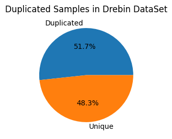

```python
duplicated_row_count = df_raw.duplicated().sum()
total_row_count = df_raw.shape[0]
duplicated_row_percentage = (duplicated_row_count/total_row_count*100)
print(f"Total rows count: {total_row_count}")
print(f"Duplicated rows count: {duplicated_row_count}")
print(f"Duplicated rows percentage: {duplicated_row_percentage}")
plt.figure(figsize=(3,3))
sizes = np.array([duplicated_row_count, total_row_count-duplicated_row_count])
labels = ['Duplicated', 'Unique']
plt.pie(sizes, labels=labels, autopct='%1.1f%%')
plt.title("Duplicated Samples in Drebin DataSet")
plt.show()
```

During this analysis we are surprised that Debrin data has quite a number of duplicates:

```
Total rows count: 15036
Duplicated rows count: 7775
Duplicated rows percentage: 51.70923117850492
```

More than half of rows in Debrin is a duplicate, we searched internet and discover a paper that mention the same problem https://ieeexplore.ieee.org/document/9609892

We decided to continue with Debrin dataset with the duplicates removed

```
Non Duplicated rows:
 7261
Check whether we have sufficient malware vs non malware data
[[3936 5540]
 [3839 1721]]
```

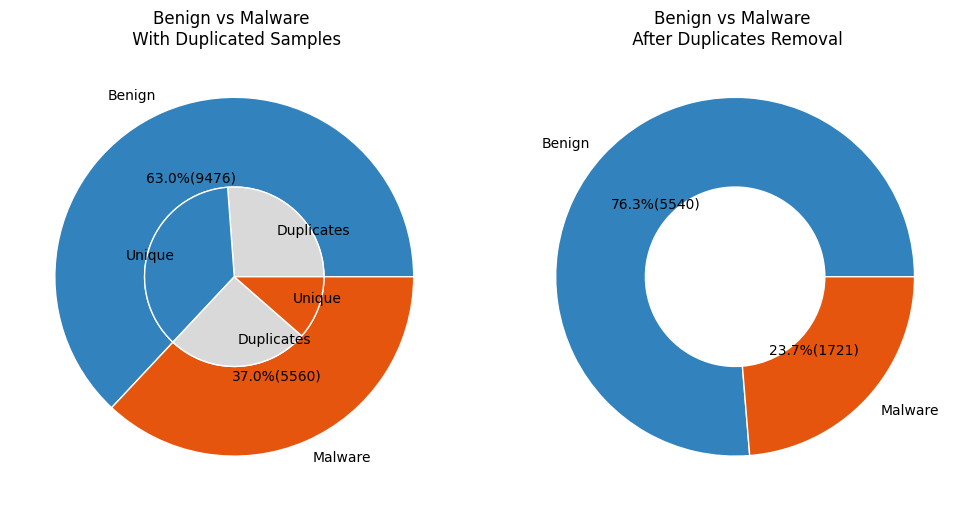

```python
def autopct_format(values):
    def my_format(pct):
        total = sum(values)
        val = int(round(pct*total/100.0))
        return '{:.1f}%({v:d})'.format(pct, v=val)
    return my_format

df_no_duplicates = df_raw.drop_duplicates()
print("Non Duplicated rows:\n", df_no_duplicates.shape[0])
print("Check whether we have sufficient malware vs non malware data")
malware_no_dup=df_no_duplicates["malware"].value_counts()
malware_original=df_raw["malware"].value_counts()
fig = plt.figure(figsize=(10, 5),layout='constrained')
ax = fig.add_subplot(1,2,1)
size = 0.5
vals = np.array([[malware_original[0]-malware_no_dup[0], malware_no_dup[0]],
                 [malware_original[1]-malware_no_dup[1], malware_no_dup[1]]])
print(vals)
tab20c = plt.color_sequences["tab20c"]
outer_colors = [tab20c[i] for i in [0, 4]]
inner_colors = [tab20c[i] for i in [19, 0,19,4]]
bm_data=vals.sum(axis=1)
ax.pie(bm_data, radius=1, colors=outer_colors, autopct=autopct_format(bm_data),
       wedgeprops=dict(width=size, edgecolor='w'), labels=["Benign", "Malware"])
bm_data=vals.flatten()
ax.pie(bm_data, radius=1-size, colors=inner_colors,
       wedgeprops=dict(width=size, edgecolor='w'),
       labeldistance=0.7, labels=["Duplicates","Unique", "Duplicates","Unique"])
ax.set(aspect="equal", title='Benign vs Malware \n With Duplicated Samples')
ax = fig.add_subplot(1,2,2)
ax.pie(malware_no_dup,colors=outer_colors,
       wedgeprops=dict(width=size, edgecolor='w'),
       labels=["Benign", "Malware"],autopct=autopct_format(malware_no_dup))
ax.set(aspect="equal", title='Benign vs Malware \n After Duplicates Removal')
plt.show()
```

After removing the duplicate rows, our data set is still reasonably sufficient and balanced for our need with

- benign sample 5540
- malware sample 1721 Roughly 23 % data shows malware and 76 % benign.

Let's deal with missing data next.

```python
df = df_no_duplicates.copy()  # replace our data frame with non-duplicated rows
```

### Handle Missing Data

```python
print("List all column with missing data")
# return ['TelephonyManager.getSimCountryIso'] as the only columen with nan value
print(df.columns[df.isna().any()].tolist())
rows_with_nan = df[df.isnull().any(axis=1)].index
no_of_rows = df.shape[0]
print("List all rows with missing data")
print(rows_with_nan)
no_of_rows_missing_data = rows_with_nan.shape[0]
print(f"Missing data is {no_of_rows_missing_data} out of {no_of_rows}")
```

```
List all column with missing data
['TelephonyManager.getSimCountryIso']
List all rows with missing data
Index([176, 2109], dtype='int64')
Missing data is 2 out of 7261
```

Given we only have 2 rows out of 7261 with missing data, let us simply remove them.

```python
df.dropna(inplace=True)
rows_with_nan = df[df.isnull().any(axis=1)].index
no_of_rows_missing_data = rows_with_nan.shape[0]
no_of_rows = df.shape[0]
print(
    f"No of rows with missing data is now {no_of_rows_missing_data} out of {no_of_rows}")
```

```
No of rows with missing data is now 0 out of 7259
```

## Split Feature vs Labels

```python
malware_index = df.columns.get_loc("malware")
print("Index of 'malware' column:", malware_index)
y = df['malware']
X =df.loc[:, df.columns != 'malware']
```

```
Index of 'malware' column: 215
```

### Splitting

Let's split our data into test and train rows

```python
# Get index of the "malware" column
from sklearn.model_selection import train_test_split
# we use our oversampled data
X_train, X_test, y_train, y_test = train_test_split(
    X, y, stratify=y, random_state=42)
print(X_train.shape)
print(X_test.shape)
```

```
(5444, 215)
(1815, 215)
```

Let's check if the data is stratified properly

```python
print("Train Data Set Output")
print(y_train.value_counts())
print(y_train.value_counts(normalize=True))
print("Test Data Set Output")
print(y_test.value_counts())
print(y_test.value_counts(normalize=True))
```

```
Train Data Set Output
malware
0    4155
1    1289
Name: count, dtype: int64
malware
0    0.763226
1    0.236774
Name: proportion, dtype: float64
Test Data Set Output
malware
0    1385
1     430
Name: count, dtype: int64
malware
0    0.763085
1    0.236915
Name: proportion, dtype: float64
```

Looks like our data is stratified and split properly

## Is Our DataSet Imbalanced ?

According to https://developers.google.com/machine-learning/crash-course/overfitting/imbalanced-datasets

We do have imbalanced dataset but it is a mild imbalanced set (20-40% of the dataset is minority case).

This is true for our dataset before and after duplicate removal

Given it is a mild case, we should first train our model using the dataset before we attempt to do any attempt to rebalance the dataset.

However, let's create an oversampled data set just in case

```
Downloading imblearn-0.0-py2.py3-none-any.whl (1.9 kB)
imblearn package is installed.
Oversampling completed.
Original class distribution:
malware
0    4155
1    1289
Name: count, dtype: int64
Oversampled class distribution:
malware
0    4155
1    4155
Name: count, dtype: int64
```

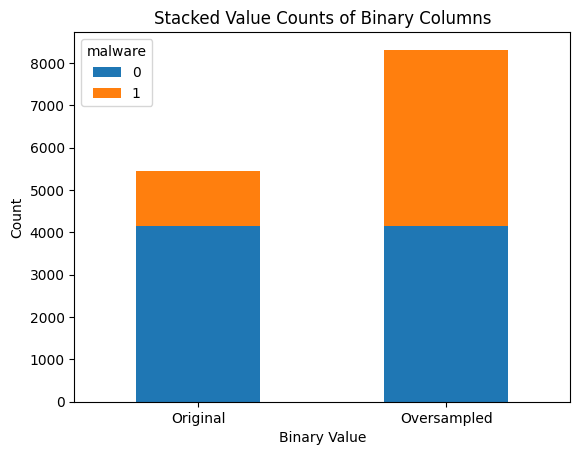

```python
%pip install imblearn
# Check if the imbalanced-learn package is installed
try:
    from imblearn.over_sampling import SMOTE
    print("imblearn package is installed.")
    oversample = SMOTE()
    over_X_train, over_y_train = oversample.fit_resample(X_train, y_train)
    print("Oversampling completed.")
    print(f"Original class distribution:\n{y_train.value_counts()}")
    print(f"Oversampled class distribution:\n{over_y_train.value_counts()}")

    plot_df = pd.DataFrame({
        'Original': y_train.value_counts(),
        'Oversampled': over_y_train.value_counts()
    }).T
    plot_df.plot(kind='bar', stacked=True, rot=0)
    plt.title('Stacked Value Counts of Binary Columns')
    plt.ylabel('Count')
    plt.xlabel('Binary Value')
    plt.show()
except ImportError:
    print("imblearn package is not installed. Please install it using 'pip install imbalanced-learn'.")
```

### Correlation Matrix

It is common to use correlation matrix for identifying feature that is redudant and can be dropped or to see relationship between features

However, given we have 215 features, it is hard to do this using visual inspection like heatmap.

Hence, we shall do a bit of code to automate analysis of correlation matrix.

```python
correlation_matrix = X_train.corr()
# set our threshold -> 1 highly correlated .. 0 not correlated
threshold = 0.8
# form pairs and sort from highest to lowest ( we want absolute value )
corr_pairs = correlation_matrix.abs().unstack().sort_values(kind="quicksort", ascending=False)
features_corrs:list[set]=[] # list of set that grow for each pair that is highly correlated
for a, b in corr_pairs.index:  # for each pair of features in the correlation matrix index
    # if a and b are not the same feature and the correlation is above the threshold
    if a!=b and corr_pairs[(a,b)] > threshold:
        new_feature_set=None
        found = False
        for feature_set in features_corrs: # for each existing set of features
            if a in feature_set or b in feature_set:  # if either a or b is in the existing set
                # expand existing set with a and b
                # set will not contain duplicate so we can add the same feature again
                feature_set.add(b) # add to existing set
                feature_set.add(a) # add to existing set
                found = True
                break
        # if there is no existing set that contains a or b
        # then we create a new set with a and b
        if not found and a!=b: # no existing set exist
            features_corrs.append(set([a,b])) # add new set
# we will count how many features we have left if we remove  highly correlated features
feature_count=(X_train.shape[1])
for feature_set in features_corrs:
    feature_count=feature_count-len(feature_set)+1 # count feature left if we remove highly correlated feature
    print(feature_set)
print("final count ", feature_count)
```

```
{'android.os.IBinder', 'IBinder', 'Binder'}
{'bindService', 'ServiceConnection', 'onServiceConnected', 'android.os.Binder'}
{'SUBSCRIBED_FEEDS_WRITE', 'SUBSCRIBED_FEEDS_READ'}
{'android.os.Binder', 'attachInterface', 'transact'}
{'Ljavax.crypto.spec.SecretKeySpec', 'KeySpec', 'Ljavax.crypto.Cipher', 'SecretKey'}
{'READ_HISTORY_BOOKMARKS', 'WRITE_HISTORY_BOOKMARKS'}
{'WRITE_SYNC_SETTINGS', 'READ_SYNC_SETTINGS'}
{'READ_USER_DICTIONARY', 'WRITE_USER_DICTIONARY'}
{'android.intent.action.SCREEN_OFF', 'android.intent.action.SCREEN_ON'}
{'RECEIVE_BOOT_COMPLETED', 'android.intent.action.BOOT_COMPLETED'}
{'Landroid.content.Context.unregisterReceiver', 'Landroid.content.Context.registerReceiver'}
{'WRITE_SOCIAL_STREAM', 'READ_SOCIAL_STREAM'}
{'READ_CALENDAR', 'WRITE_CALENDAR'}
{'HttpUriRequest', 'HttpPost.init'}
final count  195
```

The highly correlated sets look reasonable e.g {'android.intent.action.BOOT_COMPLETED', 'RECEIVE_BOOT_COMPLETED'}

indicates that the app need to listen to notification by android OS that boot completed and has ability to received the notification.

Let's build a training data set with highly correlated feature remove, just in case we need it

```python
all_columns = set(X_train.columns.to_list())
columns_to_drop=set()
for feature_set in features_corrs:
    feature_set = sorted(list(feature_set)) # prioritise read over write as read comes before write in order
    for feature in feature_set[1:]: # keep first feature
        columns_to_drop.add(feature)
columns_to_keep = all_columns - columns_to_drop
# we create both training and test data set with highly correlated feature removed
X_train_cfs = X_train.filter(items=list(columns_to_keep))
X_test_cfs = X_test.filter(items=list(columns_to_keep))
print("number of column after dropping highly correlated columns",X_train_cfs.shape[1])
print("number of column before dropping highly correlated columns",X_train.shape[1])
print("Percentage of features dropped: {:.2f}%".format((1 - X_train_cfs.shape[1] / X_train.shape[1])*100))
```

```
number of column after dropping highly correlated columns 195
number of column before dropping highly correlated columns 215
Percentage of features dropped: 9.30%
```

While it look promising, it is also quite risky to drop the features as we do not have sufficient domain knowledge to know which one to drop

## Two Classical ML Models

We would like to compare the accuracy of various classification machine learning algorithms and pick the best 2 models.

Some classification algorithm requires us to tune the hyper parameters to get the best performance e.g Decision Tree.

### Classical ML Comparison

Let's compare some well known classical ML Methods binary classifiers and pick 2 best classifiers that fit our dataset

Our candidates are :

- Logistic Regression which is commonly used for classification
- Decision Tree
- Random Forest which is a collection of Decision Tree
- Bernouli Naive Bayes which is designed specifically for binary features and binary label similar to our dataset
- K-Nearest Neighbour

We also try to detect overfitting automatically using the following indicators :

- If accuracy on training data set differ from test data set accurracy by 5%, we consider it significant enough to suspect overfitting.
- If accuracy on training data set is perfect i.e 1.0 or 100% then we suspect overfitting -> of course we need to check further

```python
from sklearn.tree import DecisionTreeClassifier
from sklearn.linear_model import LogisticRegression
from sklearn.ensemble import RandomForestClassifier
from sklearn.naive_bayes import BernoulliNB
from sklearn.neighbors import KNeighborsClassifier
# Define classifiers and run comparison
def create_classifiers():
    # Create classifiers
    # we do this so we can reuse the same classifiers for both original and highly correlated feature removed data set
    lr_clf = LogisticRegression(random_state=42)
    dt_clf = DecisionTreeClassifier(random_state=42)
    rf_clf = RandomForestClassifier(random_state=42)
    bnb_clf = BernoulliNB() # designed for binary features
    knn_clf = KNeighborsClassifier(n_neighbors=5)  # KNN with 5 neighbors
    classifiers = {
        'Bernoulli Naive Bayes': bnb_clf,
        'Decision Tree': dt_clf,
        'Logistic Regression': lr_clf,
        'Random Forest': rf_clf,
        'K-Nearest Neighbors': knn_clf
    }
    return classifiers
```

```python
from sklearn.model_selection import cross_val_score
from sklearn.model_selection import StratifiedKFold


# we create a function to evaluate the classifier so that we can reuse it
# in evaluating different classifiers
# for both classical ML and Ensemble Methods
def evaluate_classifier(clf, train_X, train_y, test_X, test_y):
    """ Evaluate the classifier using cross-validation and return various metrics.
    Args:
        clf: The classifier to evaluate.
        train_X: Training features.
        train_y: Training labels.
        test_X: Testing features.
        test_y: Testing labels.
    """
    # Create a stratified k-fold cross-validator given our data is imbalanced
    stratified_cv = StratifiedKFold(n_splits=5, shuffle=True, random_state=42)
    train_scores = cross_val_score(clf, train_X, train_y, cv=stratified_cv, scoring='accuracy') # 5-fold cross-validation

    cv_accuracy_mean = train_scores.mean()
    clf.fit(train_X, train_y) # fit the classifier on the training data
    train_accuracy = clf.score(train_X, train_y)
    test_accuracy = clf.score(test_X, test_y)
    delta_accuracy = train_accuracy - test_accuracy # difference between train and test accuracy
    cv_delta_accuracy= cv_accuracy_mean - test_accuracy # difference between cross-validation mean accuracy and test accuracy
    delta_accuracy_overfitting = (delta_accuracy > 0.05) # threshold for overfitting
    train_accuracy_overfitting = (train_accuracy >= 1.0) # if train accuracy is 100% then we consider it overfitting
    overfitting = (delta_accuracy_overfitting or train_accuracy_overfitting)
    return {
        'cv_accuracy_mean': cv_accuracy_mean,
        'train_accuracy': train_accuracy,
        'test_accuracy': test_accuracy,
        'delta_accuracy': delta_accuracy,
        'cv_delta_accuracy': cv_delta_accuracy,
        'overfitting': overfitting
    }

def compare_classifiers(train_X, train_y, test_X, test_y, classifiers, pick):
    best_clfs = []
    clfs_dict = {}
    # evaluate each classifier and store the results in a dictionary
    for label, clf in classifiers.items():
        clfs_dict[label] = evaluate_classifier(clf, train_X, train_y, test_X, test_y)
    # sort classifiers by test accuracy
    for label, value in sorted(clfs_dict.items(), key=lambda x: x[1]['cv_accuracy_mean'], reverse=True):
        print(f"{label:30} ",
              f" CV Mean Acc: {value['cv_accuracy_mean']:.5f}",
              f" Test Acc: {value['test_accuracy']:.5f}",
              f" Train Acc: {value['train_accuracy']:.5f}",
              f" Possible Overfitting: {str(value['overfitting']):5}",
              f" Delta : {value['delta_accuracy']:.5f}",
              f" CV Delta : {value['cv_delta_accuracy']:.5f}"
              )
        # pick the best classifiers based on test accuracy
        if len(best_clfs) < pick:
            best_clfs.append(label)
    print(f"\n Best {pick} classifiers: {', '.join(best_clfs)}")
```

```python
print("Compare classifiers on original data set")
print("========================================================")
compare_classifiers(X_train, y_train, X_test, y_test, create_classifiers(), pick=2)
```

```
Compare classifiers on original data set
========================================================
Random Forest                    CV Mean Acc: 0.96675  Test Acc: 0.97190  Train Acc: 1.00000  Possible Overfitting: True   Delta : 0.02810  CV Delta : -0.00515
Logistic Regression              CV Mean Acc: 0.96528  Test Acc: 0.96860  Train Acc: 0.97520  Possible Overfitting: False  Delta : 0.00661  CV Delta : -0.00331
K-Nearest Neighbors              CV Mean Acc: 0.96124  Test Acc: 0.96309  Train Acc: 0.97722  Possible Overfitting: False  Delta : 0.01414  CV Delta : -0.00184
Decision Tree                    CV Mean Acc: 0.93038  Test Acc: 0.93609  Train Acc: 1.00000  Possible Overfitting: True   Delta : 0.06391  CV Delta : -0.00571
Bernoulli Naive Bayes            CV Mean Acc: 0.82072  Test Acc: 0.82369  Train Acc: 0.82090  Possible Overfitting: False  Delta : -0.00279  CV Delta : -0.00297

 Best 2 classifiers: Random Forest, Logistic Regression
```

We found that the two best classifiers based on cross validation accuracy are 'Random Forest' and 'Logistic Regression'

We also do a quick check of overfitting between Test Data and Training Data accuracy score.

#### Overfitting

If the difference between Train and Test accuracy is > 0.05 then it is an indicator of overfitting.

Here the Decision Tree classifier exhibit this case.

Also if train accuracy has no error i.e. perfect prediction then it is possible overfitting

Hence, the random forest may also exhibit overfitting.

This could be caused by our imbalanced dataset (https://medium.com/sfu-cspmp/surviving-in-a-random-forest-with-imbalanced-datasets-b98b963d52eb)

Let's check what happened if we use our oversampled balanced dataset instead

### Compare classifier on balanced dataset

```python
print("Compare classifiers on oversampled data set")
print("========================================================")
compare_classifiers(over_X_train, over_y_train, X_test, y_test, create_classifiers(), pick=2)
```

```
Compare classifiers on oversampled data set
========================================================
Random Forest                    CV Mean Acc: 0.97413  Test Acc: 0.95978  Train Acc: 0.99928  Possible Overfitting: False  Delta : 0.03950  CV Delta : 0.01435
Logistic Regression              CV Mean Acc: 0.96197  Test Acc: 0.96088  Train Acc: 0.96907  Possible Overfitting: False  Delta : 0.00819  CV Delta : 0.00109
K-Nearest Neighbors              CV Mean Acc: 0.95945  Test Acc: 0.93884  Train Acc: 0.97581  Possible Overfitting: False  Delta : 0.03697  CV Delta : 0.02060
Decision Tree                    CV Mean Acc: 0.94597  Test Acc: 0.92837  Train Acc: 0.99928  Possible Overfitting: True   Delta : 0.07090  CV Delta : 0.01759
Bernoulli Naive Bayes            CV Mean Acc: 0.85981  Test Acc: 0.81818  Train Acc: 0.86089  Possible Overfitting: False  Delta : 0.04271  CV Delta : 0.04163

 Best 2 classifiers: Random Forest, Logistic Regression
```

Decision Tree still show overfitting but we are not going to choose this as it does not perform as good as Random Forest and Logistic Regression anyway.

Let's see if we can tune hyperparameters for our Random Forest and Logistic Regression

### Random Forest

Let's evaluate our Random Forest classifier performance and see whether we could tune its hyperparameter

```python
from sklearn.model_selection import GridSearchCV
import warnings
warnings.filterwarnings("ignore")

# Set rule to ignore warnings
param_grid = {
    'max_features': ['sqrt', 'log2'],
    'max_depth' : [4, 6, 8, 10, 12, None],
    'n_estimators': [1, 8, 16, 32, 64, 100],
}
rf_clf = RandomForestClassifier(random_state=42)
rf_clf.fit(over_X_train, over_y_train)  # fit the classifier on the training data
clf = GridSearchCV(rf_clf,param_grid = param_grid, cv = 3, verbose=False)
best_rf_clf = clf.fit(over_X_train, over_y_train)
best_rf_clf.best_estimator_
print("Best parameters for Random Forest Regression:")
print(best_rf_clf.best_params_)
print("Best score for Random Forest Regression:")
print(best_rf_clf.best_score_)
```

```
Best parameters for Random Forest Regression:
{'max_depth': None, 'max_features': 'log2', 'n_estimators': 100}
Best score for Random Forest Regression:
0.9707581227436823
```

```python
def create_tuned_random_forest_classifier():
    return RandomForestClassifier(
        max_depth=best_rf_clf.best_params_["max_depth"],
        max_features=best_rf_clf.best_params_["max_features"],
        n_estimators=best_rf_clf.best_params_["n_estimators"],
        random_state=42
    )
```

The grid search found that the best hyperparameters and we used in our create_tuned_random_forest_classifier above.

Now we check with un-tuned Random Forest Classifier and compare

```python
classifiers = {
        'Random Forest Regression': RandomForestClassifier(random_state=42),
        'Random Forest Regression Tuned': create_tuned_random_forest_classifier(),  # Use best parameters from GridSearchCV
}
compare_classifiers(over_X_train, over_y_train, X_test, y_test, classifiers, pick=1)
```

```
Random Forest Regression Tuned   CV Mean Acc: 0.97521  Test Acc: 0.96033  Train Acc: 0.99928  Possible Overfitting: False  Delta : 0.03895  CV Delta : 0.01488
Random Forest Regression         CV Mean Acc: 0.97413  Test Acc: 0.95978  Train Acc: 0.99928  Possible Overfitting: False  Delta : 0.03950  CV Delta : 0.01435

 Best 1 classifiers: Random Forest Regression Tuned
```

### Logistic Regression

Let's try to do hyper parameter tuning for our logistic regression

```python
import warnings
from sklearn.model_selection import GridSearchCV

warnings.filterwarnings("ignore")

# Set rule to ignore warnings
param_grid = [
    {'penalty':['l1','l2','elasticnet','none'],
    'solver': ['lbfgs','newton-cg','liblinear','sag','saga'],
    'C' : [0.001, 0.01, 0.1, 1, 10, 100],  # regularization strength``
}
]
lr_clf = LogisticRegression(random_state=42)
lr_clf.fit(over_X_train, over_y_train)  # fit the classifier on the training data
clf = GridSearchCV(lr_clf,param_grid = param_grid, cv = 3, verbose=False)
best_lr_clf = clf.fit(over_X_train, over_y_train)
best_lr_clf.best_estimator_
print("Best parameters for Logistic Regression:")
print(best_lr_clf.best_params_)
print("Best score for Logistic Regression:")
print(best_lr_clf.best_score_)
```

```
Best parameters for Logistic Regression:
{'C': 1, 'penalty': 'l2', 'solver': 'newton-cg'}
Best score for Logistic Regression:
0.9592057761732852
```

NOTE: running this notebook on Google Colab vs locally on laptop may result on different best parameters for Logistic Regression

Hence, we decided to pass the hyper parameters to our method instead to ensure the best parameters is always chosen regardless of the run time environment

Let's compare it with previous logistic regression before we do tuning of hyperparameter

```python
def create_tuned_logistic_regression_classifier():
        return LogisticRegression(random_state=42,
                                  C=best_lr_clf.best_params_["C"],
                                  solver=best_lr_clf.best_params_["solver"],
                                  penalty=best_lr_clf.best_params_["penalty"])
classifiers = {
        'Logistic Regression':  LogisticRegression(random_state=42),
        'Logistic Regression Tuned':  create_tuned_logistic_regression_classifier(),  # Use best parameters from GridSearchCV
}
compare_classifiers(over_X_train, over_y_train, X_test, y_test, classifiers, pick=1)
```

```
Logistic Regression Tuned        CV Mean Acc: 0.96221  Test Acc: 0.96253  Train Acc: 0.96919  Possible Overfitting: False  Delta : 0.00666  CV Delta : -0.00032
Logistic Regression              CV Mean Acc: 0.96197  Test Acc: 0.96088  Train Acc: 0.96907  Possible Overfitting: False  Delta : 0.00819  CV Delta : 0.00109

 Best 1 classifiers: Logistic Regression Tuned
```

With Tuned Logistic regression we have slightly improvement

## Voting and Stacking

We also would like to compare ensemble methods like Stacking and Voting algorithm beside simpler ML algorithm.

```python
from sklearn.ensemble import VotingClassifier, StackingClassifier
from sklearn.linear_model import LogisticRegression
from sklearn.ensemble import RandomForestClassifier

lr_clf = create_tuned_logistic_regression_classifier() # Use best parameters from GridSearchCV
rf_clf =  create_tuned_random_forest_classifier()  # Set max_depth to avoid overfitting
rf_clf_untuned = RandomForestClassifier(random_state=42) # Un-tuned Random Forest for comparison, note this performed better than untuned logistic regression

stacking_estimators = [ # we need 3 classifiers for voting ensemble methods
    ('lr', lr_clf),
    ('rf', rf_clf),
]
voting_estimators = [ # we need 3 classifiers for voting ensemble methods
    ('lr', lr_clf),
    ('rf', rf_clf),
    ('rf_untuned', rf_clf_untuned),  # Add another to provide tie-breaker capability
]

v_h_clf = VotingClassifier(estimators=voting_estimators,voting='hard')
v_s_clf = VotingClassifier(estimators=voting_estimators,voting='soft')
st_clf = StackingClassifier(estimators=stacking_estimators,
                            final_estimator=LogisticRegression(random_state=42, solver="liblinear"))


classifiers = {
    'Logistic Regression': lr_clf,
    'Random Forest': rf_clf,
    'Voting Hard Ensemble': v_h_clf,
    'Voting Soft Ensemble': v_s_clf,
    'Stacking Ensemble': st_clf,
}
best_model = None
best_model_name = None
clfs_dict = {}
# Compare classifiers and store results
# use our reduced feature set
for label, clf in classifiers.items():
    clfs_dict[label] = evaluate_classifier(clf, over_X_train, over_y_train, X_test, y_test) # reuse our function
    clfs_dict[label]['clf'] = clf  # Store the classifier object
# Print results
for label, value in sorted(clfs_dict.items(), key=lambda x: (x[1]['cv_accuracy_mean'],x[1]['train_accuracy']), reverse=True): # we should not sort by test accuracy as it is not known until we test the model actually
        print(f"{label:30} ",
              f" CV Mean: {value['cv_accuracy_mean']:.4f}",
              f" Train Acc: {value['train_accuracy']:.4f}",
              f" Test Accuracy: {value['test_accuracy']:.4f}",
              f" Possible Overfitting: {value['overfitting']}",
              f" Delta : {value['delta_accuracy']:.3f}",
              f" CV Delta : {value['cv_delta_accuracy']:.3f}",
              )
        if best_model is None:
            best_model = value
            best_model_name = label
```

```
Voting Hard Ensemble             CV Mean: 0.9764  Train Acc: 0.9993  Test Accuracy: 0.9614  Possible Overfitting: False  Delta : 0.038  CV Delta : 0.015
Stacking Ensemble                CV Mean: 0.9762  Train Acc: 0.9986  Test Accuracy: 0.9702  Possible Overfitting: False  Delta : 0.028  CV Delta : 0.006
Voting Soft Ensemble             CV Mean: 0.9756  Train Acc: 0.9980  Test Accuracy: 0.9647  Possible Overfitting: False  Delta : 0.033  CV Delta : 0.011
Random Forest                    CV Mean: 0.9752  Train Acc: 0.9993  Test Accuracy: 0.9603  Possible Overfitting: False  Delta : 0.039  CV Delta : 0.015
Logistic Regression              CV Mean: 0.9622  Train Acc: 0.9692  Test Accuracy: 0.9625  Possible Overfitting: False  Delta : 0.007  CV Delta : -0.000
```

The Ensemble methods are performing better than Random Forest and Logistic Regression

```python
st_clf
```

```
StackingClassifier(estimators=[('lr',
                                LogisticRegression(C=1, random_state=42,
                                                   solver='newton-cg')),
                               ('rf',
                                RandomForestClassifier(max_features='log2',
                                                       random_state=42))],
                   final_estimator=LogisticRegression(random_state=42,
                                                      solver='liblinear'))
```

```python
v_s_clf
```

```
VotingClassifier(estimators=[('lr',
                              LogisticRegression(C=1, random_state=42,
                                                 solver='newton-cg')),
                             ('rf',
                              RandomForestClassifier(max_features='log2',
                                                     random_state=42)),
                             ('rf_untuned',
                              RandomForestClassifier(random_state=42))],
                 voting='soft')
```

```python
v_h_clf
```

```
VotingClassifier(estimators=[('lr',
                              LogisticRegression(C=1, random_state=42,
                                                 solver='newton-cg')),
                             ('rf',
                              RandomForestClassifier(max_features='log2',
                                                     random_state=42)),
                             ('rf_untuned',
                              RandomForestClassifier(random_state=42))])
```

### Performance Evaluation

Let us check the performance of our classifiers using confusion matrix and report

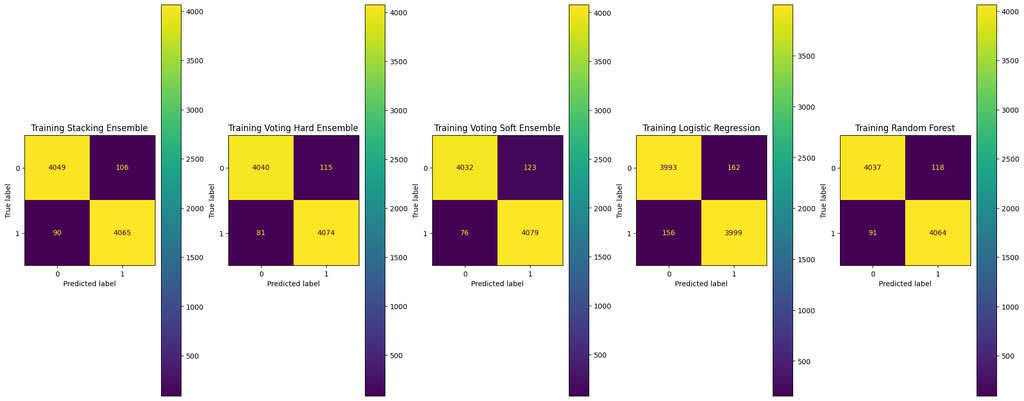

```python
from sklearn.model_selection import cross_val_predict
from sklearn.metrics import ConfusionMatrixDisplay


def display_confusion_matrix(ax, the_lr_clf, train_X, train_y, title):
    pred = cross_val_predict(the_lr_clf, train_X, train_y, cv=5)
    disp=ConfusionMatrixDisplay.from_predictions(train_y, pred,display_labels=the_lr_clf.classes_, ax=ax)
    disp.ax_.set_title(title)

fig = plt.figure(figsize=(20, 8),layout='constrained')
display_confusion_matrix(fig.add_subplot(1,5,1), st_clf,  over_X_train, over_y_train, "Training Stacking Ensemble")
display_confusion_matrix(fig.add_subplot(1,5,2), v_h_clf, over_X_train, over_y_train, "Training Voting Hard Ensemble")
display_confusion_matrix(fig.add_subplot(1,5,3), v_s_clf, over_X_train, over_y_train, "Training Voting Soft Ensemble")
display_confusion_matrix(fig.add_subplot(1,5,4), lr_clf,  over_X_train, over_y_train, "Training Logistic Regression")
display_confusion_matrix(fig.add_subplot(1,5,5), rf_clf,  over_X_train, over_y_train, "Training Random Forest")
```

For training data, our ensemble methods perform better than Logistic Regression.

```python
from sklearn.model_selection import cross_val_predict
from sklearn.metrics import classification_report

def print_classification_report(the_lr_clf, train_X, train_y, title):
    pred = cross_val_predict(the_lr_clf, train_X, train_y, cv=5)
    print(title)
    print(classification_report(train_y, pred, digits=4))

print_classification_report(st_clf, over_X_train, over_y_train, "Training Stacking Ensemble")
print_classification_report(v_s_clf, over_X_train, over_y_train, "Training Voting Soft Ensemble")
print_classification_report(v_h_clf, over_X_train, over_y_train, "Training Voting Hard Ensemble")
```

```
Training Stacking Ensemble
              precision    recall  f1-score   support

           0     0.9783    0.9745    0.9764      4155
           1     0.9746    0.9783    0.9765      4155

    accuracy                         0.9764      8310
   macro avg     0.9764    0.9764    0.9764      8310
weighted avg     0.9764    0.9764    0.9764      8310

Training Voting Soft Ensemble
              precision    recall  f1-score   support

           0     0.9815    0.9704    0.9759      4155
           1     0.9707    0.9817    0.9762      4155

    accuracy                         0.9761      8310
   macro avg     0.9761    0.9761    0.9761      8310
weighted avg     0.9761    0.9761    0.9761      8310

Training Voting Hard Ensemble
              precision    recall  f1-score   support

           0     0.9803    0.9723    0.9763      4155
           1     0.9725    0.9805    0.9765      4155

    accuracy                         0.9764      8310
   macro avg     0.9764    0.9764    0.9764      8310
weighted avg     0.9764    0.9764    0.9764      8310
```

We are intersted in Recall where Hard Voting and Stacking Ensemble has similar results Finally, let us test with our test samples. Here we simply test with our original test first instead of over sampled test

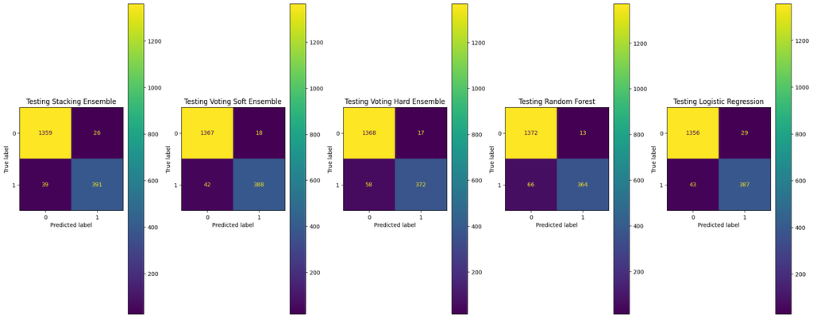

```python
fig = plt.figure(figsize=(20, 8),layout='constrained')
display_confusion_matrix(fig.add_subplot(1,5,1), st_clf, X_test, y_test, "Testing Stacking Ensemble")
display_confusion_matrix(fig.add_subplot(1,5,2), v_s_clf, X_test, y_test, "Testing Voting Soft Ensemble")
display_confusion_matrix(fig.add_subplot(1,5,3), v_h_clf, X_test, y_test, "Testing Voting Hard Ensemble")
display_confusion_matrix(fig.add_subplot(1,5,4), rf_clf, X_test, y_test, "Testing Random Forest")
display_confusion_matrix(fig.add_subplot(1,5,5), lr_clf, X_test, y_test, "Testing Logistic Regression")
```

For testing data:

- False Negative for Stacking Ensemble is the smallest
- False Positive for Stacking Ensemble and Soft voting Ensemble are not as good as Random Forest
- Random Forest has lowest False Positive but highest False Negative

Given we try to prevent malware, it is better to have smallest False Negative than False Positive.

- False Positive may cause benign application categorised as malware, it is not ideal but can improve our model by training.
- False Negative may cause a malware to be allowed to damage the system and cause harm.

Hence, the stacking ensemble performed best on actual test

## Conclusion

We discovered that in our study: